# R Notebook

## Get started

```r
library(tidyverse)
library(tidycensus)

options(scipen = 999) # Turn off scientific notation (in case it happens to be turned on)
```

## Understand the data

You can view the original text of the American Community Survey here: https://www2.census.gov/programs-surveys/acs/methodology/questionnaires/2017/quest17.pdf. This may help with interpreting some of the variables.

You can view the available variables by loading them into a “dictionary”-type table:

```r
acs5_variables <- load_variables(2017, "acs5", cache = TRUE) %>%
  separate(label, sep="!!", into=c("type", "title", "demographic_breakdown_lvl1", "demographic_breakdown_lvl2"))

View(acs5_variables)
```

Then, when you’re viewing the table, click the “Filter” button in the upper left-hand corner to toggle on the filter capabilities and start searching any of the fields to discover variables you’re interested in. It can also help to cross-reference the American FactFinder website. This lets you view the variable IDs and preview the underlying summary tables they belong to: https://factfinder.census.gov/faces/nav/jsf/pages/index.xhtml

To search for transit-related variables on American FactFinder:

1. Open the “Advanced Search”
2. In the “Topic or talble name” search box, start typing the word “Commuting”, and select “Commuting (Journey to Work)” from the drop-down options
3. For the “Dataset”, choose “2017 ACS 5-Year Estimates”
4. From the “Geographies” options, select: “County” > “Minnesota” > “All Counties within Minnesota” > “Add to Your Selections”

## Get Minnesota-wide, county-level data for transit variables we’re interested in

```r
options(tigris_use_cache = TRUE) # This will cache the geometry information so we don't have to re-download it every time

vars_by_county <- get_acs(
  geography = "county",
  variables=c(# Baseline percentages of each transit type
              "B08006_001", # Workers 16 years and over - Population (to use as our denominator)
              "B08006_003", # Means of transportation to work - Car truck or van - drove alone
              "B08006_004", # Means of transportation to work - Car truck or van - carpooled
              "B08006_008", # Means of transportation to work - Public transportation (excluding taxicab)
              "B08006_014", # Means of transportation to work - Bicycle
              "B08006_015", # Means of transportation to work - Walked
              "B08006_016", # Means of transportation to work - Taxicab motorcycle or other means
              "B08006_017", # Means of transportation to work - Worked at home

              # Median age variables
              "B08103_002", # Median age by means of transportation to work - Car truck or van - drove alone
              "B08103_003", # Median age by means of transportation to work - Car truck or van - carpooled
              "B08103_004", # Median age by means of transportation to work - Public transportation (excluding taxicab)
              "B08103_005", # Median age by means of transportation to work - Walked
              "B08103_006", # Median age by means of transportation to work - Taxicab motorcycle bicycle or other means
              "B08103_007", # Median age by means of transportation to work - Worked at home

              # Median earnings variables
              "B08121_001", # Median earnings in the past 12 months - Population
              "B08121_002", # Median earnings in the past 12 months - Car truck or van - drove alone
              "B08121_003", # Median earnings in the past 12 months - Car truck or van - carpooled
              "B08121_004", # Median earnings in the past 12 months - Public transportation (excluding taxicab)
              "B08121_005", # Median earnings in the past 12 months - Walked
              "B08121_006", # Median earnings in the past 12 months - Taxicab motorcycle bicycle or other means
              "B08121_007" # Median earnings in the past 12 months - Worked at home
              ),
  state = "MN",
  year = 2017,
  moe_level = 90,
  survey = "acs5",
  geometry = TRUE # This will download the county boundaries geometries behind the scenes so we can use them for mapping
  ) %>%
  mutate(county = gsub(" County, Minnesota", "", NAME)) # Perform some additional data clean-up to make our county names less verbose
```

## Plot stuff

### Make a bar chart

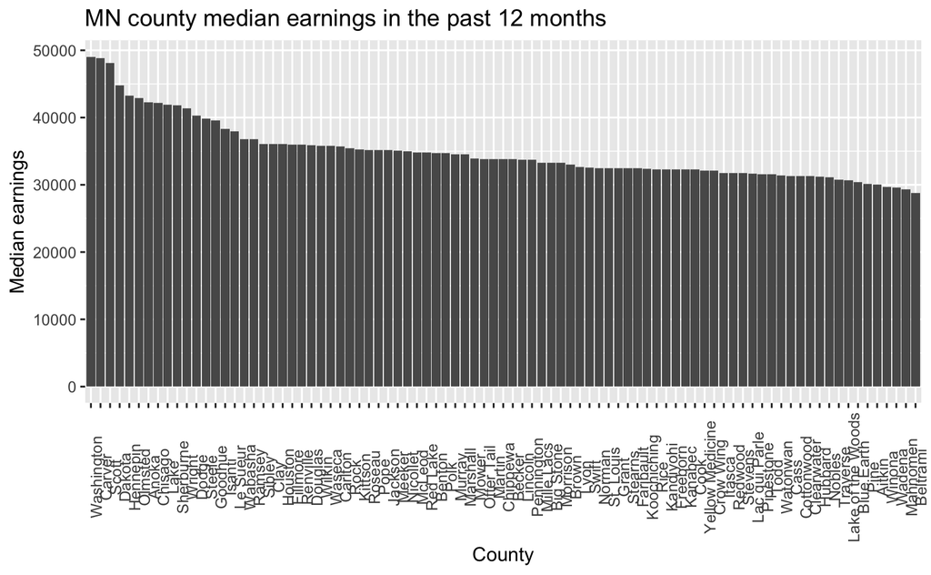

```r
vars_by_county %>%
  filter(variable=="B08121_001") %>%
ggplot(., aes(x=reorder(county, -estimate), y=estimate)) +
  geom_bar(stat="identity") +
  xlab("County") +
  ylab("Median earnings") +
  ggtitle("MN county median earnings in the past 12 months") +
  theme(axis.text.x = element_text(angle = 90))
```

Here’s a bar chart that requires computing a percentage using a denominator that aligns with the variable being examined:

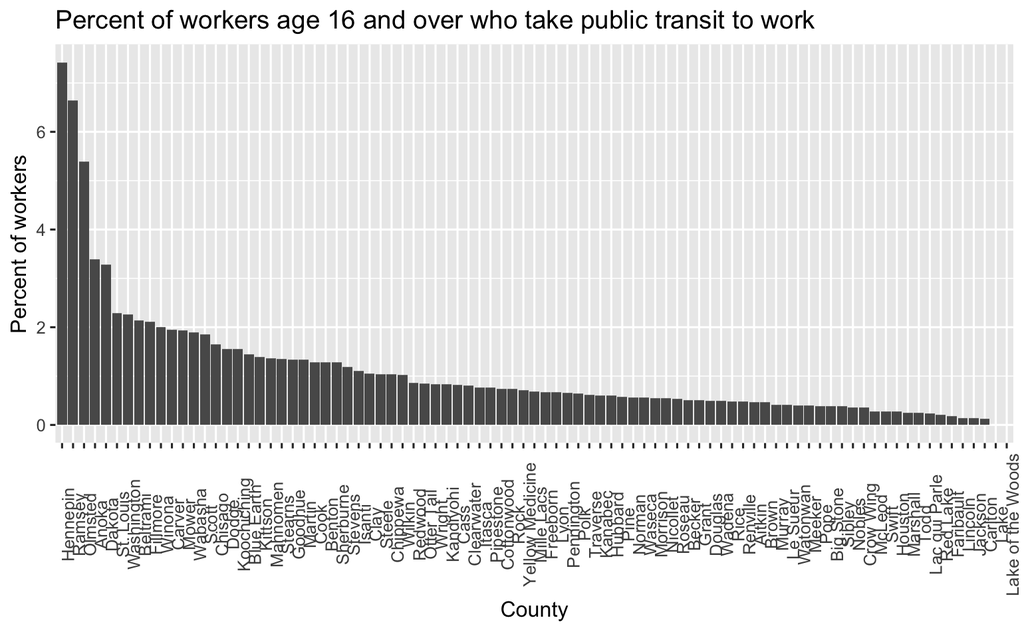

```r
vars_by_county %>%
  select(county, variable, estimate) %>%
  filter(str_detect(variable, "B08006")) %>%
  spread(key="variable", value="estimate") %>%
  mutate(pct_public_transport = (B08006_008 / B08006_001) * 100) %>%
ggplot(., aes(x=reorder(county, -pct_public_transport), y=pct_public_transport)) +
  geom_bar(stat="identity") +
  xlab("County") +
  ylab("Percent of workers") +
  ggtitle("Percent of workers age 16 and over who take public transit to work") +
  theme(axis.text.x = element_text(angle = 90))
```

### Make a map

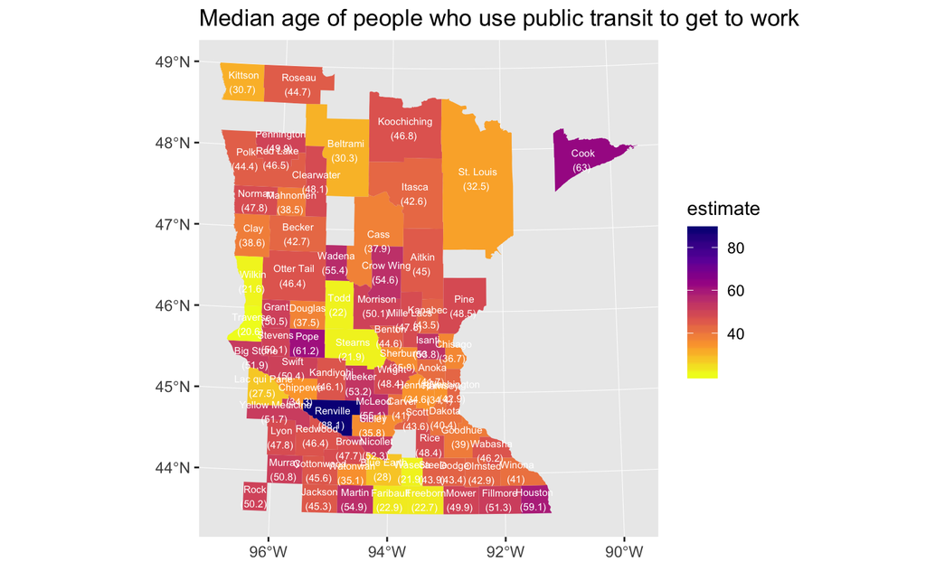

```r
vars_by_county %>%
  filter(variable=="B08103_004" # pick the variable to map
         & moe < estimate * 0.8) %>% # filter out counties where the margin of error is huge
ggplot(., aes(fill = estimate)) +
  geom_sf(color = NA) +
  coord_sf(crs = 32615) + # picking a coordinate system that should work well for MN
  geom_sf_text(aes(label=paste(county, "\n(", estimate, ") ", sep="")), size = 2, color="#ffffff") +
  scale_fill_viridis_c(option = "plasma", direction = -1) + # Use the plasma color scheme, but in reverse order so darker is on top
  ggtitle("Median age of people who use public transit to get to work") +
  xlab(NULL) +
  ylab(NULL)
```

There are a few other color schemes you can try: “viridis”, “magma”, “plasma”, “inferno”, “cividis”. These color schemes are designed to be accessible to users with colorblindness. See: https://cran.r-project.org/web/packages/viridis/vignettes/intro-to-viridis.html

### Make a stacked bar chart

This below is not working!!!

```r
vars_by_county %>%
  select(county, variable, estimate) %>%
  filter(str_detect(variable, "B08006")) %>%
  spread(key="variable", value="estimate") %>%
  mutate(pct_drove_alone = (B08006_003 / B08006_001) * 100,
         pct_carpool = (B08006_004 / B08006_001) * 100,
         pct_public_transport = (B08006_008 / B08006_001) * 100,
         pct_bicycle = (B08006_014 / B08006_001) * 100,
         pct_walked = (B08006_015 / B08006_001) * 100,
         pct_taxi_motorcycle_other = (B08006_016 / B08006_001) * 100,
         pct_work_from_home = (B08006_017 / B08006_001) * 100) %>%
  select(county, pct_drove_alone, pct_carpool, pct_public_transport, pct_bicycle, pct_walked, pct_taxi_motorcycle_other, pct_work_from_home) %>%
  gather(key="variable", value="estimate", -county)
```

## Independent living difficulty

```r
independent_living_by_county <- get_acs(
  geography = "county",
  variables=c("B18107_001", # Civilian noninstitutionalized population 18 years and over
              "B18107_004", # Male 18-34 w/ independent living difficulty
              "B18107_007", # Male 35-64 w/ independent living difficulty
              "B18107_010", # Male 65-74 w/ independent living difficulty
              "B18107_013", # Male 75 and over w/ independent living difficulty
              "B18107_017", # Female 18-34 w/ independent living difficulty
              "B18107_020", # Female 35-64 w/ independent living difficulty
              "B18107_023", # Female 65-74 w/ independent living difficulty
              "B18107_026" # Female 75 and over w/ independent living difficulty
              ),
  state = "MN",
  year = 2017,
  moe_level = 90,
  survey = "acs5",
  geometry = TRUE # This will download the county boundaries geometries behind the scenes so we can use them for mapping
  ) %>%
  mutate(county = gsub(" County, Minnesota", "", NAME)) # Perform some additional data clean-up to make our county names less verbose
```

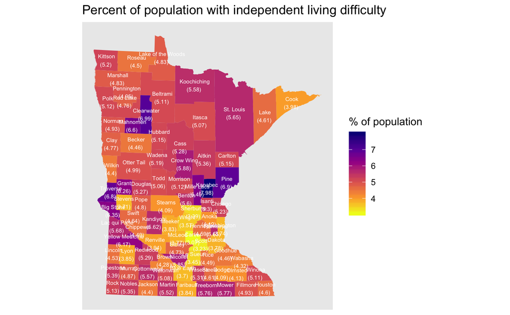

```r
independent_living_by_county %>%
  select(county, variable, estimate) %>%
  filter(str_detect(variable, "B18107")) %>%
  spread(key="variable", value="estimate") %>%
  mutate(pct_independent_living_difficulty = round(((B18107_004 + B18107_007 + B18107_010 + B18107_013 + B18107_017 + B18107_020 + B18107_023 + B18107_026) / B18107_001) * 100, 2)) %>%
ggplot(., aes(fill = pct_independent_living_difficulty)) +
  geom_sf(color = NA) +
  coord_sf(crs = 32615, datum=NA) + # picking a coordinate system that should work well for MN
  geom_sf_text(aes(label=paste(county, "\n(", pct_independent_living_difficulty, ") ", sep="")), size = 2, color="#ffffff") +
  scale_fill_viridis_c(option = "plasma", direction = -1) + # Use the plasma color scheme, but in reverse order so darker is on top
  ggtitle("Percent of population with independent living difficulty") +
  labs(fill="% of population", x=NULL, y=NULL)
```

### Older adults (and change over time)

```r
older_pop_by_county_2009 <- get_acs(
  geography = "county",
  variables=c("B01001_001", # Total population
              "B01001_020", # Male - 65 and 66 years
              "B01001_021", # Male - 67 to 69 years
              "B01001_022", # Male - 70 to 74 years
              "B01001_023", # Male - 75 to 79 years
              "B01001_024", # Male - 80 to 84 years
              "B01001_025", # Male - 85 years and over
              "B01001_044", # Female - 65 and 66 years
              "B01001_045", # Female - 67 to 69 years
              "B01001_046", # Female - 70 to 74 years
              "B01001_047", # Female - 75 to 79 years
              "B01001_048", # Female - 80 to 84 years
              "B01001_049" # Female - 85 years and over
              ),
  state = "MN",
  year = 2009,
  moe_level = 90,
  survey = "acs5",
  geometry = FALSE # This will download the county boundaries geometries behind the scenes so we can use them for mapping
  ) %>%
  mutate(county = gsub(" County, Minnesota", "", NAME)) # Perform some additional data clean-up to make our county names less verbose
```

```r
older_pop_by_county_2017 <- get_acs(
  geography = "county",
  variables=c("B01001_001", # Total population
              "B01001_020", # Male - 65 and 66 years
              "B01001_021", # Male - 67 to 69 years
              "B01001_022", # Male - 70 to 74 years
              "B01001_023", # Male - 75 to 79 years
              "B01001_024", # Male - 80 to 84 years
              "B01001_025", # Male - 85 years and over
              "B01001_044", # Female - 65 and 66 years
              "B01001_045", # Female - 67 to 69 years
              "B01001_046", # Female - 70 to 74 years
              "B01001_047", # Female - 75 to 79 years
              "B01001_048", # Female - 80 to 84 years
              "B01001_049" # Female - 85 years and over
              ),
  state = "MN",
  year = 2017,
  moe_level = 90,
  survey = "acs5",
  geometry = FALSE # This will download the county boundaries geometries behind the scenes so we can use them for mapping
  ) %>%
  mutate(county = gsub(" County, Minnesota", "", NAME)) # Perform some additional data clean-up to make our county names less verbose
```

Make the data wide, and then join:

```r
older_pop_by_county_2009_wide <- older_pop_by_county_2009 %>%
  select(county, variable, estimate) %>%
  filter(str_detect(variable, "B01001")) %>%
  spread(key="variable", value="estimate") %>%
  mutate(pct_65_and_over = round(((B01001_020 + B01001_021 + B01001_022 + B01001_023 + B01001_024 + B01001_025 + B01001_044 + B01001_045 + B01001_046 + B01001_047 + B01001_048 + B01001_049) / B01001_001) * 100, 2))

older_pop_by_county_2017_wide <- older_pop_by_county_2017 %>%
  select(county, variable, estimate) %>%
  filter(str_detect(variable, "B01001")) %>%
  spread(key="variable", value="estimate") %>%
  mutate(pct_65_and_over = round(((B01001_020 + B01001_021 + B01001_022 + B01001_023 + B01001_024 + B01001_025 + B01001_044 + B01001_045 + B01001_046 + B01001_047 + B01001_048 + B01001_049) / B01001_001) * 100, 2))

older_pop_by_county_joined <- left_join(older_pop_by_county_2009_wide, older_pop_by_county_2017_wide, by="county", suffix = c("_2009", "_2017"))
```

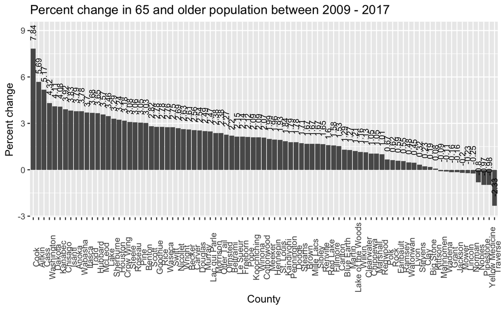

```r
older_pop_by_county_joined %>%
  mutate(pct_change_in_65_and_over = round(pct_65_and_over_2017 - pct_65_and_over_2009, 3)) %>%
ggplot(., aes(x=reorder(county, -pct_change_in_65_and_over), y=pct_change_in_65_and_over)) +
  geom_bar(stat="identity") +
  geom_text(aes(label=pct_change_in_65_and_over), angle=90, size=3, hjust=-0.5) +
  ylim(-2.5, 9) +
  xlab("County") +
  ylab("Percent change") +
  ggtitle("Percent change in 65 and older population between 2009 - 2017") +
  theme(axis.text.x = element_text(angle = 90))
```

```r
ggplot(older_pop_by_county_2017_wide, aes(fill = pct_65_and_over)) +
  geom_sf(color = NA) +
  coord_sf(crs = 32615) + # picking a coordinate system that should work well for MN
  geom_sf_text(aes(label=paste(county, "\n(", pct_65_and_over, ") ", sep="")), size = 2, color="#ffffff") +
  scale_fill_viridis_c(option = "plasma", direction = -1) + # Use the plasma color scheme, but in reverse order so darker is on top
  ggtitle("Percent of population 65 and over") +
  xlab(NULL) +
  ylab(NULL)
```

[output not shown]

### Traffic accident rates by county

```r
mn_counties <- get_acs(
  geography = "county",
  variables=c("B01001_001" # Total population
              ),
  state = "MN",
  year = 2017,
  moe_level = 90,
  survey = "acs5",
  geometry = TRUE # This will download the county boundaries geometries behind the scenes so we can use them for mapping
  ) %>%
  mutate(county = gsub(" County, Minnesota", "", NAME))
```

```
Downloading feature geometry from the Census website.  To cache shapefiles for use in future sessions, set `options(tigris_use_cache = TRUE)`.
```

```r
traffic_data <- read.csv("~/Dropbox/Open Twin Cities Projects/TransitOpportunity/mn_traffic_accidents_2018.csv", header=TRUE, stringsAsFactors = FALSE)

traffic_counties_data <- bind_cols(mn_counties, traffic_data)
```

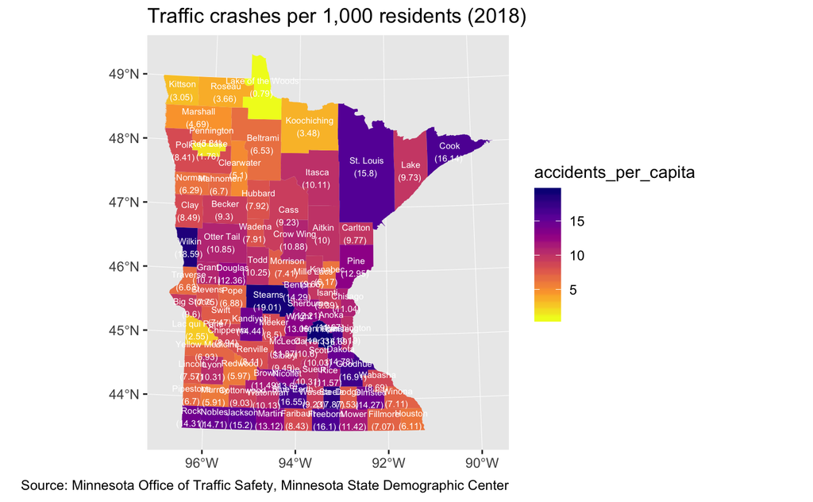

```r
traffic_counties_data %>%
  mutate(accidents_per_capita = round((AllCrashes / Population.2018) * 1000, 2)) %>%
ggplot(., aes(fill = accidents_per_capita)) +
  geom_sf(color = NA) +
  coord_sf(crs = 32615) + # picking a coordinate system that should work well for MN
  geom_sf_text(aes(label=paste(county, "\n(", accidents_per_capita, ") ", sep="")), size = 2, color="#ffffff") +
  scale_fill_viridis_c(option = "plasma", direction = -1) + # Use the plasma color scheme, but in reverse order so darker is on top
  labs(title="Traffic crashes per 1,000 residents (2018)", caption="Source: Minnesota Office of Traffic Safety, Minnesota State Demographic Center", x=NULL, y=NULL)
```

If time, look at some…

## “Careful with the denominators” variables

*Universe: Workers whose means of transportation is car, truck, or van* Universe = “B08006_002”

“B08015_001”, # Aggregate number of vehicles (car truck or van) used in commuting by workers 16 years and over - Population “B08015_002”, # Aggregate number of vehicles (car truck or van) used in commuting by workers 16 years and over - Female “B08015_003”, # Aggregate number of vehicles (car truck or van) used in commuting by workers 16 years and over - Male

*Universe: Workers 16 years and over who did not work at home* Universe = “B08006_001” - “B08006_017”

“B08013_001”, # Aggregate travel time to work (in minutes) - Population “B08013_002”, # Aggregate travel time to work (in minutes) - Female “B08013_003”, # Aggregate travel time to work (in minutes) - Male